# Prelim 2 Review: solutions to selected textbook exercises

October 30, 2018

# One Population Mean

## 5.4

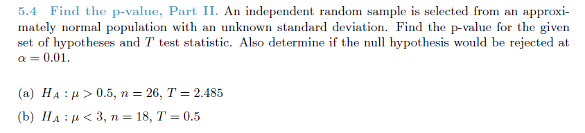

1. $H_A: \mu > 0.5$, so the p-value is the area to the right of observed test statistic. (draw picture)

```r
pvalue = 1-pt(2.485, df=25)
pvalue
```

```
## [1] 0.0100024
```

alternately,

```r
pvalue = pt(2.485, df=25, lower.tail=FALSE)
pvalue
```

```
## [1] 0.0100024
```

2. $H_A: \mu < 3$, so the p-value is the area to the left of observed test statistic. (draw picture)

```r
pvalue = pt(.5, df=17)
pvalue
```

```
## [1] 0.6882574
```

Sine $p > \alpha$, we will fail to reject the null hypothesis at $\alpha = 0.01$.

## 5.12

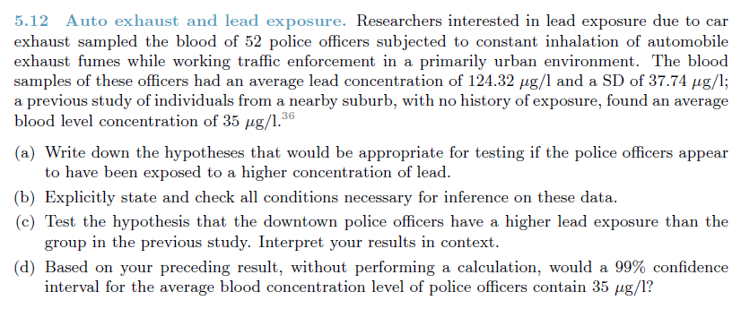

1. Let $\mu$ be the population average lead concentration (in $\mu$g/l) of police officers subjected to inhalation of automobile exhaust fumes.

Our hypotheses are
$$H_0: \mu = 35, \, \, H_A: \mu > 35$$

2. Assumptions:
   - police officers are sampled independently of each other
   - Sample size $n = 52$ is large enough to assume that the sample mean is approximately normal (by Central Limit Theorem)
3. Test statistic = $\frac{124.32-35}{37.74/\sqrt{52}}$. Under null, it follows a t distribution with $n-1 = 51$ degrees of freedom.

p-value = $P(T > obs)$

```r
n = 52; xbar = 124.32; mu0 = 35; s = 37.74
teststat = (xbar-mu0)/(s/sqrt(n))
pvalue = pt(teststat, df=n-1, lower.tail=FALSE)
pvalue # p-value using t-test
```

```
## [1] 4.956975e-23
```

```r
pvalue_z = pnorm(teststat, lower.tail=FALSE)
pvalue_z # p-value using z-test
```

```
## [1] 1.314098e-65
```

Since p-value is less than $1\%$, we reject $H_0$ at $1\%$ level of significance.

In other words, at $1\%$ level of significance, we have enough evidence to believe that downtown police officers have higher lead exposure than the group in the previous study.

4. The p-value for a two-sided test $H_0: \mu = 35, \, \, H_A: \mu \neq 35$ based on this data will be less than $.01$

```r
2*pvalue
```

```
## [1] 9.913949e-23
```

and we will reject $H_0$ in favor of $H_A$.

So, by duality of 99% confidence interval and a two-sided hypothesis test at 1% level of significance, we can say that the $99\%$ confidence interval for the average blood concentration level of police officers based on this data will not contain the null value $35\mu$g/l.

# One population proportion

## 6.12

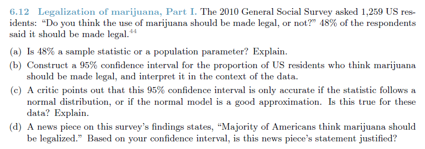

1. sample statistic, since the 1259 selected residents form only a subset of the entire population of US residents.
2. sample statistic $\hat{p} = 0.48$,

standard error $SE(\hat{p}) = \sqrt{\frac{\hat{p}(1-\hat{p})}{n}}$,

$\alpha = 5\%$, so multiplier = $z_{\alpha/2} \approx 1.96$,

95% confidence interval: $(\hat{p} - 1.96 \times SE(\hat{p}), \hat{p} + 1.96 \times SE(\hat{p}))$. In R, we use a slightly more accurate value of the multiplier:

```r
alpha = 0.05; n = 1259; phat = 0.48; se = sqrt(phat*(1-phat)/n)
z = -qnorm(alpha/2)
z
```

```
## [1] 1.959964
```

```r
lower = phat - z*se
upper = phat+z*se

lower
```

```
## [1] 0.4524033
```

```r
upper
```

```
## [1] 0.5075967
```

3. Yes, since $n \hat{p} = 1259 \times 0.48$ and $n (1-\hat{p}) = 1259 \times 0.52$ are both larger than $10$, we can assume that the normal model for $\hat{p}$ is a good approximation.
4. No, since the 95% confidence interval contains the value $0.5$, a test of $H_0: p = 0.5$ vs. $H_A: p \neq 0.5$ at $5\%$ level of significance will fail to reject $H_0$. So the conclusion of the newspaper is not justified.

## 6.16

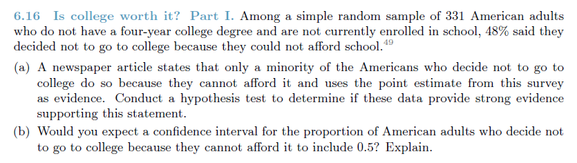

1. Let $p$ denote the population proportion of all Americans who decide not to go to college because they cannot afford it.

Our null and alternative hypotheses are:

$H_0: p = 0.5$ vs. $H_A: p < 0.5$. (research question in alternative hypothesis)

sample statistic $\hat{p} = 0.48$, sample size $n = 331$

test statistic $z = \frac{\hat{p}-0.5}{\sqrt{0.5*(1-0.5)/n}}$. Under null, the test statistic follows an approximate N(0,1) distribution.

pvalue = $P(Z < obs)$

```r
phat = 0.48; n = 331; p0 = 0.5
teststat = (0.48-0.5)/(sqrt(0.5*(1-0.5)/n))
teststat
```

```
## [1] -0.7277362
```

```r
pvalue = pnorm(teststat)
pvalue
```

```
## [1] 0.2333875
```

Since pvalue is larger than $0.01$, we fail to reject null at $1\%$ level of significance.

In other words, at $1\%$ level of significance, we do not have sufficient evidence that a minority of Americans who decide not to go to college do so because they cannot afford it.

2. Yes.

# Paired Mean

## 5.18

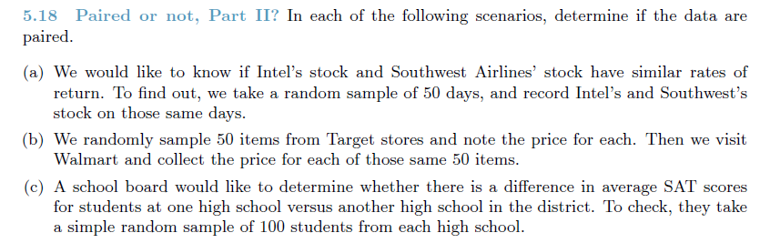

1. paired
2. paired
3. not paired